# Lab 2

Peter Gansallo

2024-10-24

# Part 1

Load critstats package

```r
# Use the remote install function to call in your data
# remotes::install_github("professornaite/critstats", force=TRUE)

# Loading the `critstats` library
library(critstats)

# update the `critstats` package if needed
update.packages("critstats")
```

Look at datasets in critstats

```r
data(package = 'critstats')
```

## Report 1.1

Decided to use the data in gss_cat

### Examine and understand the gss_cat data

Look at how many rows, columns, variable names, levels and data types

```r
str(gss_cat)
```

```
## tibble [21,483 × 9] (S3: tbl_df/tbl/data.frame)
##  $ year   : int [1:21483] 2000 2000 2000 2000 2000 2000 2000 2000 2000 2000 ...
##  $ marital: Factor w/ 6 levels "No answer","Never married",..: 2 4 5 2 4 6 2 4 6 6 ...
##  $ age    : int [1:21483] 26 48 67 39 25 25 36 44 44 47 ...
##  $ race   : Factor w/ 4 levels "Other","Black",..: 3 3 3 3 3 3 3 3 3 3 ...
##  $ rincome: Factor w/ 16 levels "No answer","Don't know",..: 8 8 16 16 16 5 4 9 4 4 ...
##  $ partyid: Factor w/ 10 levels "No answer","Don't know",..: 6 5 7 6 9 10 5 8 9 4 ...
##  $ relig  : Factor w/ 16 levels "No answer","Don't know",..: 15 15 15 6 12 15 5 15 15 15 ...
##  $ denom  : Factor w/ 30 levels "No answer","Don't know",..: 25 23 3 30 30 25 30 15 4 25 ...
##  $ tvhours: int [1:21483] 12 NA 2 4 1 NA 3 NA 0 3 ...
```

## Report 1.2

The two variables we’ll investigate is the marital and relig variable in gss cat

## Report 1.3

#### Is there an association between religion and divorce rates in the U.S?

```r
gss_cat_df <- gss_cat
```

Take a peak at the data

```r
head(gss_cat_df)
```

```
## # A tibble: 6 × 9
##    year marital         age race  rincome        partyid     relig denom tvhours
##   <int> <fct>         <int> <fct> <fct>          <fct>       <fct> <fct>   <int>
## 1  2000 Never married    26 White $8000 to 9999  Ind,near r… Prot… Sout…      12
## 2  2000 Divorced         48 White $8000 to 9999  Not str re… Prot… Bapt…      NA
## 3  2000 Widowed          67 White Not applicable Independent Prot… No d…       2
## 4  2000 Never married    39 White Not applicable Ind,near r… Orth… Not …       4
## 5  2000 Divorced         25 White Not applicable Not str de… None  Not …       1
## 6  2000 Married          25 White $20000 - 24999 Strong dem… Prot… Sout…      NA
```

## Report 1.4

I’m going to look at the data in the dataset, check for missing values, in the age, religion, and marital status which I’m interested in. Then I’m going to convert the age column from an int and change it a factor having 3 factors, “early stage” from 18-34, “mid stage” from 35-49, and “late stage” 50+(this won’t be apart of the analysis so I’ll look at this correlation at the ed of the report). I’m going to combine the different religions into three categories, “Christian”, “Other World Religion”, and “Non Religious”. Then I’ll make marital a two factor variable “Divorced/Seperated” and “Married”, I’ll remove “no answer”,“Never Married” ,and “widowed” in the marital status column. I’ll then do a chi squared test to test the two categorical variables Marital Status and Religion, to see if there’s enough correlation to reject the null hypothesis which is that there’s no correlation between religion and marital status.

## Report 1.5

The data not being evenly spread out is a potential limitation, as some factors in each of the columns we’re investigating have a larger number of observations which can possible affect our conclusions.

# Part 2

Part 2 reports will mostly be in order, and some will be at the bottom of the analysis ### Understanding the data of the latest year in the dataset

```r
max(gss_cat_df$year)
```

```
## [1] 2014
```

Inspect the data now that we’re looking at 2014

```r
gss2014 <- filter(gss_cat_df, year == 2014)
str(gss2014)
```

```
## tibble [2,538 × 9] (S3: tbl_df/tbl/data.frame)
##  $ year   : int [1:2538] 2014 2014 2014 2014 2014 2014 2014 2014 2014 2014 ...
##  $ marital: Factor w/ 6 levels "No answer","Never married",..: 4 6 4 6 6 6 6 6 2 6 ...
##  $ age    : int [1:2538] 53 26 59 56 74 56 63 34 37 30 ...
##  $ race   : Factor w/ 4 levels "Other","Black",..: 3 3 3 3 3 3 3 3 3 1 ...
##  $ rincome: Factor w/ 16 levels "No answer","Don't know",..: 4 4 16 7 16 4 3 4 16 4 ...
##  $ partyid: Factor w/ 10 levels "No answer","Don't know",..: 5 5 4 5 7 4 4 2 7 7 ...
##  $ relig  : Factor w/ 16 levels "No answer","Don't know",..: 14 14 15 14 14 15 14 14 14 14 ...
##  $ denom  : Factor w/ 30 levels "No answer","Don't know",..: 30 30 15 30 30 5 30 30 30 30 ...
##  $ tvhours: int [1:2538] NA NA 4 2 NA 1 4 2 NA NA ...
```

Take a look at the unique values of religion and of marital status

```r
table(gss2014$marital)
```

```
##
##     No answer Never married     Separated      Divorced       Widowed
##             4           675            81           411           209
##       Married
##          1158
```

Take a look at the unique values of religion

```r
table(gss2014$relig)
```

```
##
##               No answer              Don't know Inter-nondenominational
##                      15                       3                       4
##         Native american               Christian      Orthodox-christian
##                       2                     134                       9
##            Moslem/islam           Other eastern                Hinduism
##                       9                       3                      13
##                Buddhism                   Other                    None
##                      26                      27                     522
##                  Jewish                Catholic              Protestant
##                      40                     606                    1125
##          Not applicable
##                       0
```

## Report 1.6 and Report 1.7

### Clean up the data

We see there are some data we won’t include in our analysis Remove the data we won’t include in our analysis Religion: - No answer; ineffective for our analysis (15) - Don’t know; ineffective for our analysis (3) - Inter-nondenominational; doesn’t fall under christian, other world religion or not religious categories (4) - other eastern; doesn’t fall under christian, other world religion or not religious categories (3) - native american; doesn’t fall under christian, other world religion or not religious categories (2)

Marital: - No answer; ineffective for our analysis (4) - Never married; ineffective for our analysis (675) - Widowed; might make the analysis a little noisy, as there are things we can’t account for (209)

```r
cleaned_2014_gss <- gss2014 %>%
  # we'll filter out some factors from the relig and marital category
  filter(relig != "No answer",
         relig != "Don't know",
         relig != "Other",
         relig != "Not applicable",
         relig != "Inter-nondenominational",
         relig != "Native american",
         relig != "Other eastern",
         marital != "No answer",
         marital != "Never married",
         marital != "Widowed") %>%
  droplevels()
cleaned_2014_gss #take a peak at the cleaned tibble
```

```
## # A tibble: 1,619 × 9
##     year marital    age race  rincome        partyid         relig denom tvhours
##    <int> <fct>    <int> <fct> <fct>          <fct>           <fct> <fct>   <int>
##  1  2014 Divorced    53 White $25000 or more Not str republ… Cath… Not …      NA
##  2  2014 Married     26 White $25000 or more Not str republ… Cath… Not …      NA
##  3  2014 Divorced    59 White Not applicable Strong republi… Prot… Luth…       4
##  4  2014 Married     56 White $10000 - 14999 Not str republ… Cath… Not …       2
##  5  2014 Married     74 White Not applicable Independent     Cath… Not …      NA
##  6  2014 Married     56 White $25000 or more Strong republi… Prot… Epis…       1
##  7  2014 Married     63 White Refused        Strong republi… Cath… Not …       4
##  8  2014 Married     34 White $25000 or more Don't know      Cath… Not …       2
##  9  2014 Married     30 Other $25000 or more Independent     Cath… Not …      NA
## 10  2014 Married     43 Other Not applicable Independent     Cath… Not …      NA
## # ℹ 1,609 more rows
```

Take a look at the unique values of religion again

```r
table(cleaned_2014_gss$relig)
```

```
##
##          Christian Orthodox-christian       Moslem/islam           Hinduism
##                 85                  7                  6                  8
##           Buddhism               None             Jewish           Catholic
##                 19                300                 24                402
##         Protestant
##                768
```

Take a look at the unique values of marital again

```r
table(cleaned_2014_gss$marital)
```

```
##
## Separated  Divorced   Married
##        80       404      1135
```

Now we need to also look at the age categories as I’m sure this will play a role in the marital rates

```r
table(cleaned_2014_gss$age)
```

```
##
## 20 22 23 24 25 26 27 28 29 30 31 32 33 34 35 36 37 38 39 40 41 42 43 44 45 46
##  1  2  1  6 11 14 13 12 30 31 31 31 33 25 24 29 30 34 40 33 38 28 44 26 31 22
## 47 48 49 50 51 52 53 54 55 56 57 58 59 60 61 62 63 64 65 66 67 68 69 70 71 72
## 35 26 32 45 32 33 51 44 42 42 35 51 36 38 31 33 31 34 34 23 33 20 16 17 18 14
## 73 74 75 76 77 78 79 80 81 82 83 84 85 86 87 88 89
## 16 20  9 14 10 14 12  8  8  6  5  5  4  5  1  5  6
```

### income cleanup

```r
table(gss2014$rincome)
```

```
##
##      No answer     Don't know        Refused $25000 or more $20000 - 24999
##              0             19             73            951            143
## $15000 - 19999 $10000 - 14999  $8000 to 9999  $7000 to 7999  $6000 to 6999
##             87            111             30             14             24
##  $5000 to 5999  $4000 to 4999  $3000 to 3999  $1000 to 2999       Lt $1000
##             32             25             38             36             32
## Not applicable
##            923
```

### Age cleanup

```r
final2014gss <- cleaned_2014_gss %>%
 mutate(age_group = fct_collapse(as.factor(age),#like recode but supports range
#Unknown levels in `f`: 18, 19, 21 after doing more filters, so changing to suite the data properly and now changing category to 20-34 from 18-34
                                          "20-34" = as.character(20),
                                          "20-34" = as.character(22:34),
                                          "35-49" = as.character(35:49),
                                          "50+" = as.character(50:89))) %>%
 mutate(religion = fct_recode(relig,
                                     "Christian" = "Christian",
                                     "Christian" = "Catholic",
                                     "Christian" = "Protestant",
                                     "Christian" = "Orthodox-christian",
                                     "Other World Religions" = "Hinduism",
                                     "Other World Religions" = "Buddhism",
                                     "Other World Religions" = "Moslem/islam",
                                     "Other World Religions" = "Jewish")) %>%
 mutate(marital_status = fct_recode(marital,
                                    "Separated/Divorced" = "Separated",
                                    "Separated/Divorced" = "Divorced"))
table(final2014gss$age_group)
```

```
##
## 20-34 35-49   50+
##   241   472   901
```

```r
table(final2014gss$religion)
```

```
##
##             Christian Other World Religions                  None
##                  1262                    57                   300
```

```r
table(final2014gss$marital_status)
```

```
##
## Separated/Divorced            Married
##                484               1135
```

Reduce to only the categories we’ll analyze

```r
final2014gss <- final2014gss %>%
  select(religion, marital_status, age_group)
```

## Report 1.6

### Null Cleanup

```r
sapply(final2014gss, function(x) sum(is.na(x)))
```

```
##       religion marital_status      age_group
##              0              0              5
```

After cleaning up the data we see that we only have 5 null values in age which we’ll remove and should be our last cleanup

```r
final2014gss <- na.omit(final2014gss)
sapply(final2014gss, function(x) sum(is.na(x)))
```

```
##       religion marital_status      age_group
##              0              0              0
```

## Report 1.8

### Take a look at the relationship between the variables

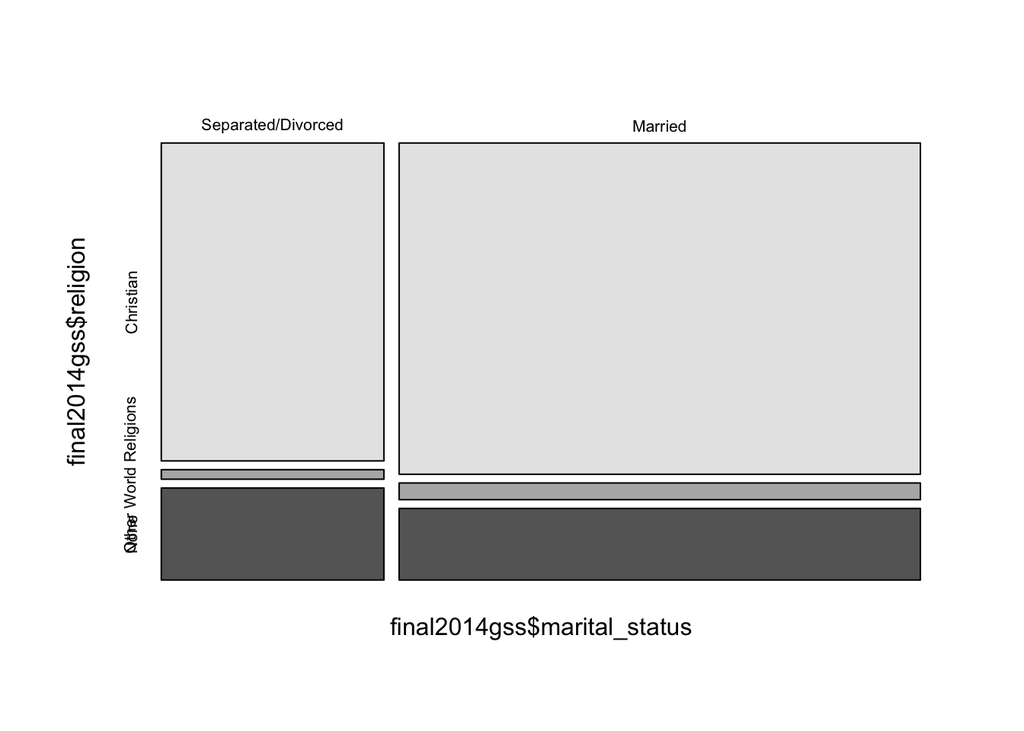

```
##    Cell Contents
## |-------------------------|
## |                   Count |
## |             Row Percent |
## |-------------------------|
##
## =============================================================
##                          final2014gss$marital_status
## final2014gss$religion    Separated/Divorced   Married   Total
## -------------------------------------------------------------
## Christian                              366       893    1259
##                                       29.1%     70.9%   78.0%
## -------------------------------------------------------------
## Other World Religions                   11        45      56
##                                       19.6%     80.4%    3.5%
## -------------------------------------------------------------
## None                                   106       193     299
##                                       35.5%     64.5%   18.5%
## -------------------------------------------------------------
## Total                                  483      1131    1614
## =============================================================
```

```r
crosstab(final2014gss$religion, final2014gss$marital_status,
         prop.r = T)
```

It seems the percentages show that religious people are more likely to be married still

### Chi-Squared analysis

```r
# get critical value of chi-square, p=.05, df = 1
# df = (r-1)(c-1)
qchisq(.05, 2, lower.tail = F)
```

```
## [1] 5.991465
```

```r
# get the chi square stat
chisq.test(final2014gss$religion, final2014gss$marital_status)
```

```
##
##  Pearson's Chi-squared test
##
## data:  final2014gss$religion and final2014gss$marital_status
## X-squared = 7.6163, df = 2, p-value = 0.02219
```

### Visualization

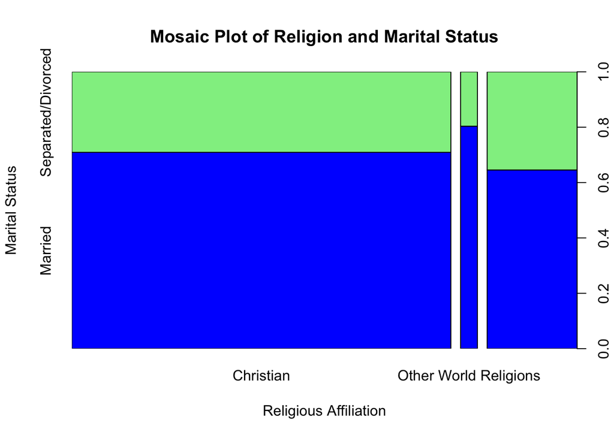

```r
plot(final2014gss$religion, final2014gss$marital_status,
     main = "Mosaic Plot of Religion and Marital Status",
     col = c("Blue","lightgreen"),
     xlab = "Religious Affiliation",
     ylab = "Marital Status")
```

## Report 1.9

The chi-squared test results show that there’s statistically significant association between religious affiliation and marital status, suggesting that religious identity may indeed influence marital stability. The theory that religious communities often promote marital stability through shared beliefs and practices, contributing to lower rates of marital breakdown among religious individuals seems true. The results support this notion, as both Christian and Other World Religions have higher proportions of married individuals compared to those with no religious affiliation.

## Report 1.10

### Age and marital status correlation

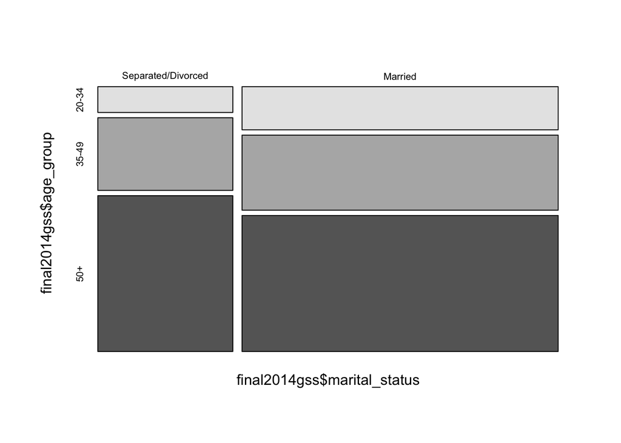

```
##    Cell Contents
## |-------------------------|
## |                   Count |
## |             Row Percent |
## |-------------------------|
##
## ==============================================================
##                           final2014gss$marital_status
## final2014gss$age_group    Separated/Divorced   Married   Total
## --------------------------------------------------------------
## 20-34                                    49       192     241
##                                        20.3%     79.7%   14.9%
## --------------------------------------------------------------
## 35-49                                   138       334     472
##                                        29.2%     70.8%   29.2%
## --------------------------------------------------------------
## 50+                                     296       605     901
##                                        32.9%     67.1%   55.8%
## --------------------------------------------------------------
## Total                                   483      1131    1614
## ==============================================================
```

```r
crosstab(final2014gss$age_group, final2014gss$marital_status,
         prop.r = T)
```

### Chi-Squared analysis

```r
# get critical value of chi-square, p=.05, df = 1
# df = (r-1)(c-1)
qchisq(.05, 2, lower.tail = F)
```

```
## [1] 5.991465
```

```r
# get the chi square stat
chisq.test(final2014gss$age_group, final2014gss$marital_status)
```

```
##
##  Pearson's Chi-squared test
##
## data:  final2014gss$age_group and final2014gss$marital_status
## X-squared = 14.365, df = 2, p-value = 0.0007599
```